# ESIEE-Paris: 2025 - 2026

Projet 2 : Analyse Factorielle Discriminante (AFD) sur Tweets

Ryane SID IDRIS - Badr TAJINI

2026-02-14

# 1. Introduction

L’objectif de ce projet est d’analyser les sentiments (Positif, Négatif, Neutre, Irrelevant) extraits de tweets concernant diverses entités (marques, jeux vidéo, etc.) .

Pour ce faire, nous utilisons une méthode de réduction de dimension et de classification supervisée : l’Analyse Factorielle Discriminante (AFD). Cette méthode permet de projeter les données dans un espace réduit tout en maximisant la séparation entre les classes de sentiments.

# 2. Méthodologie et Pré-traitement

Nous commençons par charger les librairies nécessaires à la manipulation des données, au traitement du texte (NLP) et à la modélisation statistique.

```r
library(tidyverse)
library(tm)
library(SnowballC)
library(MASS)
library(caret)
library(kableExtra)
```

# 2.1 Chargement des données

Nous utilisons le jeu de données Twitter Entity Sentiment Analysis. Nous chargeons un échantillon pour optimiser le temps de calcul.

```r
df <- read.csv("twitter_training.csv", header = FALSE, stringsAsFactors = FALSE, nrows = 5000)
colnames(df) <- c("TweetID", "Entity", "Sentiment", "TweetContent")

df <- df %>%
  dplyr::select(Sentiment, TweetContent) %>%
  filter(TweetContent != "") %>%
  drop_na()

df$Sentiment <- as.factor(df$Sentiment)

corpus <- VCorpus(VectorSource(df$TweetContent))

clean_text <- function(c) {
  c <- tm_map(c, content_transformer(tolower))
  c <- tm_map(c, removePunctuation)
  c <- tm_map(c, removeNumbers)
  c <- tm_map(c, removeWords, stopwords("en"))
  c <- tm_map(c, stripWhitespace)
  return(c)
}

corpus_clean <- clean_text(corpus)

dtm <- DocumentTermMatrix(corpus_clean, control = list(weighting = weightTfIdf))
dtm_sparse <- removeSparseTerms(dtm, 0.99)

data_model <- as.data.frame(as.matrix(dtm_sparse))
data_model <- data_model[, sapply(data_model, function(v) var(v, na.rm=TRUE) != 0)]

data_model$Sentiment <- df$Sentiment

numeric_cols <- sapply(data_model, is.numeric)
data_model <- data_model[rowSums(data_model[, numeric_cols]) > 0, ]

cat("Dimensions finales de la matrice :", dim(data_model))
```

```
## Dimensions finales de la matrice : 4338 143
```

# 3. Implémentation de l’AFD

Nous divisons les données et appliquons l’AFD.

```r
set.seed(42)

index <- createDataPartition(data_model$Sentiment, p = 0.8, list = FALSE)
train <- data_model[index, ]
test  <- data_model[-index, ]

lda_model <- lda(Sentiment ~ ., data = train)

prop_lda <- lda_model$svd^2 / sum(lda_model$svd^2)
print(round(prop_lda, 3))
```

```
## [1] 0.445 0.323 0.233
```

# 4. Résultats et Visualisation

Nous projetons les tweets sur les deux premiers axes discriminants (LD1 et LD2) pour visualiser la séparation des classes.

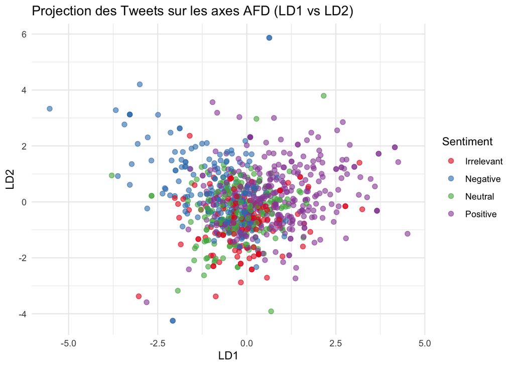

```r
lda_pred <- predict(lda_model, test)
dataset_viz <- data.frame(Sentiment = test$Sentiment, lda_pred$x)

ggplot(dataset_viz, aes(x = LD1, y = LD2, color = Sentiment)) +
  geom_point(alpha = 0.6, size = 2) +
  theme_minimal() +
  labs(title = "Projection des Tweets sur les axes AFD (LD1 vs LD2)",
       x = "LD1", y = "LD2") +
  scale_color_brewer(palette = "Set1")
```

L’axe horizontal sépare bien les tweets Négatifs (Bleus) des Positifs (Violets). Par contre, les tweets Neutres et Irrelevant se mélangent au centre, ce qui explique pourquoi la précision du modèle plafonne à 55%.

# 4.1 Évaluation de la classification

Nous évaluons la précision du modèle pour prédire le sentiment.

```r
cm <- confusionMatrix(lda_pred$class, test$Sentiment)

cm$table %>%
  kbl(caption = "Matrice de Confusion") %>%
  kable_styling(bootstrap_options = "striped", full_width = F)
```

Matrice de Confusion

|  | Irrelevant | Negative | Neutral | Positive |
| --- | --- | --- | --- | --- |
| Irrelevant | 44 | 25 | 12 | 19 |
| Negative | 16 | 72 | 14 | 19 |
| Neutral | 11 | 41 | 95 | 52 |
| Positive | 56 | 45 | 81 | 264 |

```r
cat("Précision (Accuracy) :", round(cm$overall['Accuracy'] * 100, 2), "%")
```

```
## Précision (Accuracy) : 54.85 %
```

Avec une précision de 54,85 %, le modèle surpasse le hasard (25%). Le premier axe (LD1) capture 44,5 % de la variance, ce qui permet de bien séparer les sentiments Négatifs et Positifs sur le graphique. Ce plan factoriel est fiable car il conserve 77 % de l’information totale. Enfin, la matrice de confusion montre que le modèle est très efficace pour identifier les avis Positifs avec 264 bonnes prédictions.

# 5. Conclusion

Ce projet a permis d’appliquer l’Analyse Factorielle Discriminante (AFD) sur un jeu de données de tweets.